# Firm sentiments ±14 days

Gopal Penny

4/18/2021

# Consider stock returns within 14 days of quarterly reports

Building on the initial analysis considering [quarterly growth](https://gopalpenny.github.io/firmsentiments/firm-sentiments-proposal.html), I now perform a similar analysis using growth with a time period that spans ±14 days of the quarterly earnings report. To begin, I identify all market records within this time window of each earnings report.

```r
library(data.table)
library(tidyverse)

if (file.exists("data/format/stocks_28day_avg_growth.csv")) {
  stocks_28day_growth <- read_csv("data/format/stocks_28day_avg_growth.csv")
} else {
  # Read firmrisk to data.table
  firmrisk <- fread("data/format/firmquarter_2020q4.csv")
  firmrisk <- firmrisk[, .(year_quarter = date, ticker, Risk, Sentiment, date_earningscall)]
  firmrisk <- firmrisk[, RollDate := date_earningscall - 45] # Shift join data by 45 days for rolling join

  # Read stock histories to data.table
  stocks <- fread("data/format/yfinance_stock_histories.csv")
  stocks <- stocks[order(ticker, date), .(Close, date, ticker)]
  stocks <- stocks[, `:=`(RollDate = date, CloseLag = shift(Close)), by = ticker] # to calculate daily growth
  stocks <- stocks[, `:=`(CloseGrowth = (Close - CloseLag)/CloseLag)]

  # dt_test <- setDT(data.frame(num = 1:7, group = c("a","a","b","b","b","c","c")))

  # Set join keys
  setkey(stocks, ticker, RollDate)
  setkey(firmrisk, ticker, RollDate)

  # Join stocks and firmrisk data, using rolling date match
  stocks_growth_rolljoin <- firmrisk[stocks, roll = TRUE, nomatch = 0]

  # Filter stock growth data to be within 14 days of earnings call
  stocks_growth_28day_all <- stocks_growth_rolljoin[abs(date_earningscall - date) <= 14]

  # Get 28-day average stock growth, centered on the date of the earnings call
  stocks_28day_growth <- as_tibble(stocks_growth_28day[, .(avg_growth = mean(CloseGrowth, na.rm = TRUE),
                                                           sd_growth = sd(CloseGrowth, na.rm = TRUE),
                                                           Risk = first(Risk), Sentiment = first(Sentiment)),
                                                       by = .(ticker, year_quarter, date_earningscall)])

  rm(list = c("stocks", "stocks_growth_rolljoin", "stocks_growth_28day_all"))

  write_csv(stocks_28day_growth, "data/format/stocks_28day_avg_growth.csv")
}
```

## Average 28-day growth

I then remove any outliers, determined as the interquartile range (IQR) ±1.5 times the IQR. These outliers may be important and I will consider them in greater detail later – for now, looking at the aggregate statistics, it is fine to ignore. I then run the same regression as presented in the proposal:

```r
# Identify outliers in average 28day growth
stocks_28day_growth_IQR <- quantile(stocks_28day_growth$avg_growth, c(0.25, 0.75), na.rm = TRUE)
stocks_28day_growth_IQR_outliers <- stocks_28day_growth_IQR +
  (stocks_28day_growth_IQR[2] - stocks_28day_growth_IQR[1]) * c(-1.5, 1.5)
stocks_28day_growth <- stocks_28day_growth %>%
  mutate(outlier = !between(avg_growth, stocks_28day_growth_IQR_outliers[1], stocks_28day_growth_IQR_outliers[2]))


firms_df <- stocks_28day_growth %>% filter(!outlier)

lm_28day_all <- summary(lm(Sentiment ~ avg_growth, firms_df))
lm_28day_all
```

```
##
## Call:
## lm(formula = Sentiment ~ avg_growth, data = firms_df)
##
## Residuals:
##     Min      1Q  Median      3Q     Max
## -4406.3  -336.4    -2.5   339.4  3246.7
##
## Coefficients:
##             Estimate Std. Error t value Pr(>|t|)
## (Intercept)  776.912      1.358   572.1   <2e-16 ***
## avg_growth  8705.605    261.447    33.3   <2e-16 ***
## ---
## Signif. codes:  0 '***' 0.001 '**' 0.01 '*' 0.05 '.' 0.1 ' ' 1
##
## Residual standard error: 532.4 on 155727 degrees of freedom
##   (6 observations deleted due to missingness)
## Multiple R-squared:  0.007069,   Adjusted R-squared:  0.007063
## F-statistic:  1109 on 1 and 155727 DF,  p-value: < 2.2e-16
```

There is a small increase in R<sup>2</sup> from 0.006 to 0.007.

```r
# Group the average 28day growth into 10 equal-sized bins, and do the same for Sentiment scores.
firms_df_binned <- firms_df %>%
  mutate(avg_growth_bins = cut(avg_growth, quantile(avg_growth, seq(0, 1, by = 0.1), na.rm = TRUE), include.lowest = TRUE),
         sentiment_bins = cut(Sentiment, quantile(Sentiment, seq(0, 1, by = 0.1), na.rm = TRUE), include.lowest = TRUE))

# Get the lower limit of each bin
avg_growth_bins_ll <- as.numeric(gsub("(\\()|(\\[)|(,.*)", "", levels(firms_df_binned$avg_growth_bins)))
sentiment_bins_ll <- as.numeric(gsub("(\\()|(\\[)|(,.*)", "", levels(firms_df_binned$sentiment_bins)))#)
```

## Binned average quarterly growth

Just as before, I grouped the average growth into 10 equal-sized bins, and did the same for Sentiment scores.

```r
firms_df_binned_growth_means <- firms_df_binned %>%
  group_by(avg_growth_bins) %>%
  summarize(mean_growth = mean(avg_growth, na.rm = TRUE),
            mean_sentiment = mean(Sentiment, na.rm = TRUE))

lm_growth_binned <- summary(lm(mean_sentiment ~ mean_growth, firms_df_binned_growth_means))
lm_growth_binned
```

```
##
## Call:
## lm(formula = mean_sentiment ~ mean_growth, data = firms_df_binned_growth_means)
##
## Residuals:
##     Min      1Q  Median      3Q     Max
## -41.593  -4.646   1.146  14.876  19.858
##
## Coefficients:
##             Estimate Std. Error t value Pr(>|t|)
## (Intercept)  776.821      6.455 120.341 2.54e-14 ***
## mean_growth 8858.790   1266.384   6.995 0.000113 ***
## ---
## Signif. codes:  0 '***' 0.001 '**' 0.01 '*' 0.05 '.' 0.1 ' ' 1
##
## Residual standard error: 20.27 on 8 degrees of freedom
## Multiple R-squared:  0.8595, Adjusted R-squared:  0.8419
## F-statistic: 48.93 on 1 and 8 DF,  p-value: 0.0001132
```

From the binned growth data set, I then predicted mean sentiment using mean quarterly growth, both averaged within quarterly growth bin. The OLS regression produces a much higher R<sup>2</sup> of 0.86.

```r
firms_df_binned_sentiment_means <- firms_df_binned %>%
  group_by(sentiment_bins) %>%
  summarize(mean_growth = mean(avg_growth,na.rm = TRUE),
            mean_sentiment = mean(Sentiment,na.rm = TRUE))

lm_sentiment_binned <- summary(lm(mean_sentiment ~ mean_growth, firms_df_binned_sentiment_means))
lm_sentiment_binned
```

```
##
## Call:
## lm(formula = mean_sentiment ~ mean_growth, data = firms_df_binned_sentiment_means)
##
## Residuals:
##      Min       1Q   Median       3Q      Max
## -135.832  -41.404   -4.803   61.939   90.419
##
## Coefficients:
##              Estimate Std. Error t value Pr(>|t|)
## (Intercept) 8.082e+01  4.283e+01   1.887   0.0959 .
## mean_growth 1.176e+06  5.796e+04  20.288 3.64e-08 ***
## ---
## Signif. codes:  0 '***' 0.001 '**' 0.01 '*' 0.05 '.' 0.1 ' ' 1
##
## Residual standard error: 79.99 on 8 degrees of freedom
##   (1 observation deleted due to missingness)
## Multiple R-squared:  0.9809, Adjusted R-squared:  0.9786
## F-statistic: 411.6 on 1 and 8 DF,  p-value: 3.641e-08
```

From the binned sentiment data set, predict mean sentiment using mean quarterly growth, both averaged within sentinment bins. The OLS regression produces an high R<sup>2</sup> of 0.98.

## Average quarterly growth versus Sentiment

The following plot shows average average 28-day growth versus average sentiment for all year-quarter combinations as well as for both summaries of binned data.

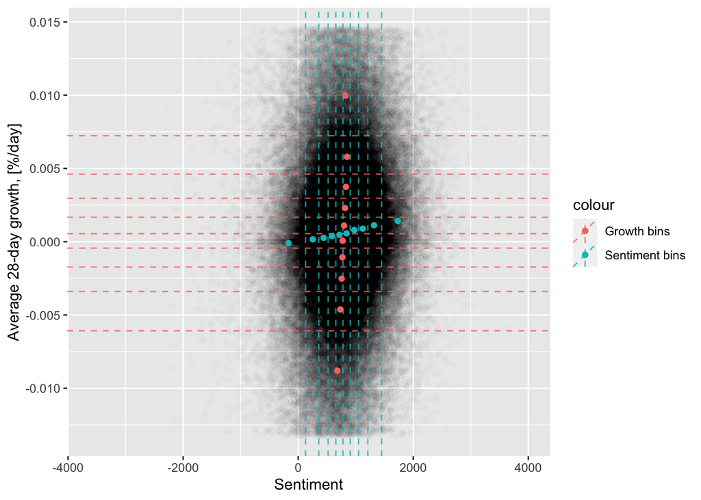

```r
lm_coefficients <- rbind(with(lm_28day_all, c(coefficients[,1], coefficients[2,4], r.squared)),
                         with(lm_growth_binned, c(coefficients[,1], coefficients[2,4], r.squared)),
                         with(lm_sentiment_binned, c(coefficients[,1], coefficients[2,4], r.squared))) %>%
  as_tibble() %>% set_names(c("intercept", "slope", "p_val_slope", "regression_r_squared"))

ggplot() +
  geom_point(data = firms_df, aes(avg_growth, Sentiment), alpha = 0.01) +
  geom_vline(data = data.frame(intercept = avg_growth_bins_ll[-1]),
              aes(xintercept = intercept,color = "Growth bins"), alpha = 0.75, linetype = "dashed") +
  geom_abline(data = data.frame(intercept = sentiment_bins_ll[-1], slope = 0),
              aes(slope = slope, intercept = intercept,color = "Sentiment bins"), alpha = 0.75, linetype = "dashed") +
  geom_point(data = firms_df_binned_sentiment_means, aes(mean_growth, mean_sentiment, color = "Sentiment bins")) +
  geom_point(data = firms_df_binned_growth_means, aes(mean_growth, mean_sentiment, color = "Growth bins")) +
  xlab("Average 28-day growth, [%/day]") +
  coord_flip()
```